# Lab 5

Author

Nathan Weitershausen

# Setup

```r
library(data.table)
library(dtplyr)
library(dplyr)
# Read met
met <- read.csv("C:/Users/nweit/Downloads/met_all.gz")
met$USAFID <- as.integer(met$USAFID)

met <- met[met$temp > -17, ]

# Download stations data
stations <- read.csv("https://noaa-isd-pds.s3.amazonaws.com/isd-history.csv")
stations$USAF <- as.integer(stations$USAF)
# Dealing with blanks and 999999
stations$USAF[stations$USAF == 999999] <- NA
stations$CTRY[stations$CTRY == ""] <- NA
stations$STATE[stations$STATE == ""] <- NA

# Selecting the three relevant columns, and keeping unique records
stations <- unique(stations[, c('USAF', 'CTRY', 'STATE')])

# Dropping NAs
stations <- stations[!is.na(stations$USAF), ]

# Removing duplicates
stations <- stations[!duplicated(stations$USAF), ]

dat <- merge(
  # Data
  x     = met,
  y     = stations,
  # List of variables to match
  by.x  = "USAFID",
  by.y  = "USAF",
  # Which obs to keep?
  all.x = TRUE,
  all.y = FALSE
  )

head(dat[, c('USAFID', 'WBAN', 'STATE')], n = 4)
```

```
  USAFID  WBAN STATE
1 690150 93121    CA
2 690150 93121    CA
3 690150 93121    CA
4 690150 93121    CA
```

# Question 1: Representative station for the US

What is the median station in terms of temperature, wind speed, and atmospheric pressure? Look for the three weather stations that best represent continental US using the quantile() function. Do these three coincide?

```r
dat2 <- dat |>
  group_by(USAFID) |>
  summarize(Median_Temp = median(temp, na.rm = TRUE),
            Median_Wind.Speed = median(wind.sp, na.rm = TRUE), Median_Atmospheric.Pressure = median(atm.press, na.rm = TRUE)) |>
  arrange (USAFID) |>
  filter(!is.na(Median_Temp), !is.na(Median_Wind.Speed), !is.na(Median_Atmospheric.Pressure))

National_Median <- dat2 |>
  summarize(
    Median_Temp = quantile(Median_Temp, 0.50, na.rm = TRUE),
    Median_Wind.Speed = quantile(Median_Wind.Speed, 0.50, na.rm = TRUE), Median_Atmospheric.Pressure = quantile(Median_Atmospheric.Pressure, 0.50, na.rm = TRUE))

National_Median
```

```
# A tibble: 1 × 3
  Median_Temp Median_Wind.Speed Median_Atmospheric.Pressure
        <dbl>             <dbl>                       <dbl>
1        23.3               2.6                       1015.
```

```r
Temperature_Station <-dat2 |>
  slice_min(abs(dat2$Median_Temp - National_Median$Median_Temp), n = 1, with_ties = FALSE)
Wind.Speed_Station <-dat2 |>
  slice_min(abs(dat2$Median_Wind.Speed - National_Median$Median_Wind.Speed), n = 1, with_ties = FALSE)
Atmospheric.Pressure_Station <-dat2|>
  slice_min(abs(dat2$Median_Atmospheric.Pressure - National_Median$Median_Atmospheric.Pressure), n = 1, with_ties = FALSE)

National_Median_Stations <- data.frame(Variable = c("Temperature", "Wind Speed", "Atmospheric Pressure"), USAFID = c(Temperature_Station$USAFID, Wind.Speed_Station$USAFID, Atmospheric.Pressure_Station$USAFID), National_Median = c(National_Median$Median_Temp, National_Median$Median_Wind.Speed, National_Median$Median_Atmospheric.Pressure))

National_Median_Stations
```

```
              Variable USAFID National_Median
1          Temperature 720306            23.3
2           Wind Speed 720369             2.6
3 Atmospheric Pressure 720394          1014.6
```

## Summary

The median station for temperature was station 720306, the median station for wind speed was station 720369, and the median station for atmospheric pressure was station 720394. The three stations do not coincide.

# Question 2: Representative Station per State

As in the previous question, calculate the median latitude and longitude for stations in each state.

```r
dat3 <- dat |>
  group_by(STATE, USAFID) |>
  summarize(Latitude = median(lat, na.rm = TRUE), Longitude = median(lon, na.rm = TRUE))|> filter(!is.na(STATE), !is.na(USAFID), !is.na(Latitude), !is.na(Longitude))
```

[output not shown]

```r
State_Medians <- dat3 |>
  group_by(STATE) |>
  summarize(Median_Latitude = quantile(Latitude, probs = 0.50, na.rm = TRUE), Median_Longitude = quantile(Longitude, probs = 0.50, na.rm = TRUE))

State_Medians
```

```
# A tibble: 48 × 3
   STATE Median_Latitude Median_Longitude
   <chr>           <dbl>            <dbl>
 1 AL               32.8            -86.6
 2 AR               35.5            -92.7
 3 AZ               33.5           -112.
 4 CA               36.3           -120.
 5 CO               39.2           -106.
 6 CT               41.4            -72.8
 7 DE               39.1            -75.5
 8 FL               28.4            -81.8
 9 GA               32.6            -83.3
10 IA               41.8            -93.5
# ℹ 38 more rows
```

# Question 3: In the middle?

For each state, identify the station that is closest to the mean latitude and longitude for stations in that state. Combining these with the coordinates you identified in the previous question, use leaflet() to visualize all ~100 points in the same figure, applying different colors for those identified in this question.

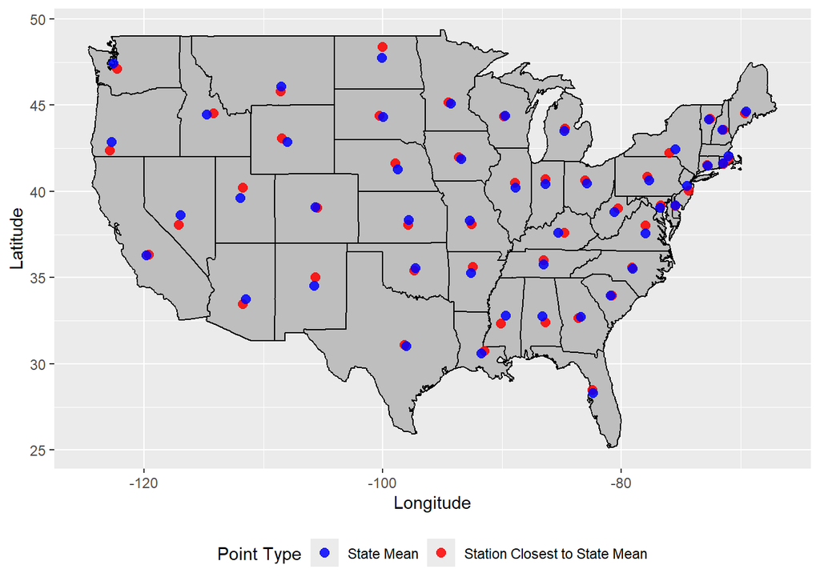

```r
library(ggplot2)

State_Coordinates <- dat3 |>
  group_by(STATE) |>
  summarize(Mean_Latitude = mean(Latitude, na.rm = TRUE), Mean_Longitude = mean(Longitude, na.rm = TRUE))

Mean_Stations <- dat3 |>
  left_join(State_Coordinates |>
  select(STATE, Mean_Latitude, Mean_Longitude), by = "STATE") |>
  mutate(Distance_from_Mean = sqrt((Latitude - Mean_Latitude)^2 + (Longitude - Mean_Longitude)^2)) |>
  group_by(STATE) |>
  slice_min(Distance_from_Mean, n=1, with_ties = FALSE)

ggplot(map_data("state"), aes(x = long, y = lat)) +
  geom_map(aes(map_id= region), map = map_data("state"), col = "black", fill = "gray") +
  geom_point(data = Mean_Stations, mapping = aes(x = Longitude, y = Latitude, colour = "Station Closest to State Mean"), size = 2.5, alpha = 0.85) +
  geom_point(data = State_Coordinates, mapping = aes(x = Mean_Longitude, y = Mean_Latitude, colour = "State Mean"),  size = 2.5, alpha = 0.85) +
  scale_color_manual(name = "Point Type", values = c("Station Closest to State Mean" = "red", "State Mean" = "blue")) +
  labs(y  = "Latitude", x = "Longitude") +
  theme(legend.position = "bottom")
```

# Question 4: Means of Means

Compute each state’s average temperature and use that to classify them according to the following criteria:

low: temp < 20 Mid: temp >= 20 and temp < 25 High: temp >= 25 Now generate a large summary table with states/observations split into the three categories listed above. For each group, compute the following:

Number of states Number of entries (records) Number of NA entries Number of stations Mean temperature Mean wind-speed Mean atmospheric pressure

```r
Average_Temperature_Categorized <- dat |>
  group_by(STATE) |>
  mutate(Average_Temp_State = mean(temp, na.rm= TRUE),
  Temperature_Category = ifelse(Average_Temp_State < 20, "Low", ifelse(Average_Temp_State < 25, "Mid", "High")))

Summary <- Average_Temperature_Categorized |>
  filter(!is.na(Temperature_Category)) |>
  group_by(Temperature_Category) |>
  summarize(Number_of_States = n_distinct(STATE), Number_of_Entries = n(), Number_of_NA_Entries = sum(is.na(temp)), Number_of_Stations = n_distinct(USAFID, na.rm = TRUE), Mean_Temperature = mean(temp, na.rm = TRUE), Mean_Wind_Speed = mean(wind.sp, na.rm = TRUE), Mean_Atmospheric_Pressure = mean(atm.press, na.rm = TRUE))

Summary
```

```
# A tibble: 3 × 8
  Temperature_Category Number_of_States Number_of_Entries Number_of_NA_Entries
  <chr>                           <int>             <int>                <int>
1 High                               12            787619                    0
2 Low                                11            423414                    0
3 Mid                                25           1106171                    0
# ℹ 4 more variables: Number_of_Stations <int>, Mean_Temperature <dbl>,
#   Mean_Wind_Speed <dbl>, Mean_Atmospheric_Pressure <dbl>
```